# Case study 1 - How does a bike-share navigate speedy success?

Donovan Rodriguez

2023-04-27

## Exercise Full Year Analysis

This analysis is the case study “‘How does a bike-share navigate speedy success?’ (found here: https://divvy-tripdata.s3.amazonaws.com/index.html). The purpose of this analysis is to practice the skills learned in the course.

```r
library(tidyverse)
library(lubridate)
getwd()
```

```
## [1] "/Users/donovanrodriguez/Documents/GitHub/mcriders/docs"
```

```r
setwd("/Users/donovanrodriguez/Documents/Database/CSV")
```

### Step 1 Collected Data

```r
J01 <- read_csv("/Users/donovanrodriguez/Documents/Database/CSV/202201-divvy-tripdata.csv")
F02 <- read.csv("/Users/donovanrodriguez/Documents/Database/CSV/202202-divvy-tripdata.csv")

M03 <- read_csv("/Users/donovanrodriguez/Documents/Database/CSV/202203-divvy-tripdata.csv")
A04 <- read.csv("/Users/donovanrodriguez/Documents/Database/CSV/202204-divvy-tripdata.csv")

M05 <- read_csv("/Users/donovanrodriguez/Documents/Database/CSV/202205-divvy-tripdata.csv")
J06 <- read_csv("/Users/donovanrodriguez/Documents/Database/CSV/202206-divvy-tripdata.csv")
J07 <- read_csv("/Users/donovanrodriguez/Documents/Database/CSV/202207-divvy-tripdata.csv")
A08 <- read_csv("/Users/donovanrodriguez/Documents/Database/CSV/202208-divvy-tripdata.csv")
S09 <- read_csv("/Users/donovanrodriguez/Documents/Database/CSV/202209-divvy-publictripdata.csv")
O10 <- read_csv("/Users/donovanrodriguez/Documents/Database/CSV/202210-divvy-tripdata.csv")
N11 <- read_csv("/Users/donovanrodriguez/Documents/Database/CSV/202211-divvy-tripdata.csv")
D12 <- read_csv("/Users/donovanrodriguez/Documents/Database/CSV/202212-divvy-tripdata.csv")
```

### Step 2 Wrangle data and combine into a single file

```r
colnames(J01)
```

```
##  [1] "ride_id"            "rideable_type"      "started_at"
##  [4] "ended_at"           "start_station_name" "start_station_id"
##  [7] "end_station_name"   "end_station_id"     "start_lat"
## [10] "start_lng"          "end_lat"            "end_lng"
## [13] "member_casual"
```

```r
colnames(F02)
```

```
##  [1] "ride_id"            "rideable_type"      "started_at"
##  [4] "ended_at"           "start_station_name" "start_station_id"
##  [7] "end_station_name"   "end_station_id"     "start_lat"
## [10] "start_lng"          "end_lat"            "end_lng"
## [13] "member_casual"
```

```r
colnames(M03)
```

```
##  [1] "ride_id"            "rideable_type"      "started_at"
##  [4] "ended_at"           "start_station_name" "start_station_id"
##  [7] "end_station_name"   "end_station_id"     "start_lat"
## [10] "start_lng"          "end_lat"            "end_lng"
## [13] "member_casual"
```

```r
colnames(A04)
```

```
##  [1] "ride_id"            "rideable_type"      "started_at"
##  [4] "ended_at"           "start_station_name" "start_station_id"
##  [7] "end_station_name"   "end_station_id"     "start_lat"
## [10] "start_lng"          "end_lat"            "end_lng"
## [13] "member_casual"
```

```r
colnames(M05)
```

```
##  [1] "ride_id"            "rideable_type"      "started_at"
##  [4] "ended_at"           "start_station_name" "start_station_id"
##  [7] "end_station_name"   "end_station_id"     "start_lat"
## [10] "start_lng"          "end_lat"            "end_lng"
## [13] "member_casual"
```

```r
colnames(J06)
```

```
##  [1] "ride_id"            "rideable_type"      "started_at"
##  [4] "ended_at"           "start_station_name" "start_station_id"
##  [7] "end_station_name"   "end_station_id"     "start_lat"
## [10] "start_lng"          "end_lat"            "end_lng"
## [13] "member_casual"
```

```r
colnames(J07)
```

```
##  [1] "ride_id"            "rideable_type"      "started_at"
##  [4] "ended_at"           "start_station_name" "start_station_id"
##  [7] "end_station_name"   "end_station_id"     "start_lat"
## [10] "start_lng"          "end_lat"            "end_lng"
## [13] "member_casual"
```

```r
colnames(A08)
```

```
##  [1] "ride_id"            "rideable_type"      "started_at"
##  [4] "ended_at"           "start_station_name" "start_station_id"
##  [7] "end_station_name"   "end_station_id"     "start_lat"
## [10] "start_lng"          "end_lat"            "end_lng"
## [13] "member_casual"
```

```r
colnames(S09)
```

```
##  [1] "ride_id"            "rideable_type"      "started_at"
##  [4] "ended_at"           "start_station_name" "start_station_id"
##  [7] "end_station_name"   "end_station_id"     "start_lat"
## [10] "start_lng"          "end_lat"            "end_lng"
## [13] "member_casual"
```

```r
colnames(O10)
```

```
##  [1] "ride_id"            "rideable_type"      "started_at"
##  [4] "ended_at"           "start_station_name" "start_station_id"
##  [7] "end_station_name"   "end_station_id"     "start_lat"
## [10] "start_lng"          "end_lat"            "end_lng"
## [13] "member_casual"
```

```r
colnames(N11)
```

```
##  [1] "ride_id"            "rideable_type"      "started_at"
##  [4] "ended_at"           "start_station_name" "start_station_id"
##  [7] "end_station_name"   "end_station_id"     "start_lat"
## [10] "start_lng"          "end_lat"            "end_lng"
## [13] "member_casual"
```

```r
colnames(D12)
```

```
##  [1] "ride_id"            "rideable_type"      "started_at"
##  [4] "ended_at"           "start_station_name" "start_station_id"
##  [7] "end_station_name"   "end_station_id"     "start_lat"
## [10] "start_lng"          "end_lat"            "end_lng"
## [13] "member_casual"
```

```r
J01 <-  mutate(J01, ride_id = as.character(ride_id)
                   ,rideable_type = as.character(rideable_type))

F02 <-  mutate(F02, ride_id = as.character(ride_id)
                   ,rideable_type = as.character(rideable_type))

M03 <-  mutate(M03, ride_id = as.character(ride_id)
                   ,rideable_type = as.character(rideable_type))

A04 <-  mutate(A04, ride_id = as.character(ride_id)
                   ,rideable_type = as.character(rideable_type))

M05 <-  mutate(M05, ride_id = as.character(ride_id)
                   ,rideable_type = as.character(rideable_type))

J06 <-  mutate(J06, ride_id = as.character(ride_id)
                   ,rideable_type = as.character(rideable_type))

J07 <-  mutate(J07, ride_id = as.character(ride_id)
                   ,rideable_type = as.character(rideable_type))

A08 <-  mutate(A08, ride_id = as.character(ride_id)
                   ,rideable_type = as.character(rideable_type))

S09 <-  mutate(S09, ride_id = as.character(ride_id)
                   ,rideable_type = as.character(rideable_type))

O10 <-  mutate(O10, ride_id = as.character(ride_id)
                   ,rideable_type = as.character(rideable_type))

N11 <-  mutate(N11, ride_id = as.character(ride_id)
                   ,rideable_type = as.character(rideable_type))

D12 <-  mutate(D12, ride_id = as.character(ride_id)
                   ,rideable_type = as.character(rideable_type))
```

```r
F02$started_at <- ymd_hms(F02$started_at, tz = "UTC")
F02$ended_at <- ymd_hms(F02$ended_at, tz = "UTC")
M03$started_at <- ymd_hms(M03$started_at, tz = "UTC")
M03$ended_at <- ymd_hms(M03$ended_at, tz = "UTC")
A04$started_at <- ymd_hms(A04$started_at, tz = "UTC")
A04$ended_at <- ymd_hms(A04$ended_at, tz = "UTC")
```

#### Stack individual quarter’s data frames into one big data frame

```r
all_trips <- bind_rows(J01, F02, M03, A04, M05, J06, J07, A08, S09, O10, N11, D12)
```

### Step 3 Clean up and add data to prepare for analysis

#### Inspect the new table that has been created

```r
colnames(all_trips)  #List of column names
```

```
##  [1] "ride_id"            "rideable_type"      "started_at"
##  [4] "ended_at"           "start_station_name" "start_station_id"
##  [7] "end_station_name"   "end_station_id"     "start_lat"
## [10] "start_lng"          "end_lat"            "end_lng"
## [13] "member_casual"
```

```r
nrow(all_trips)  #How many rows are in data frame?
```

```
## [1] 5667717
```

```r
dim(all_trips)  #Dimensions of the data frame?
```

```
## [1] 5667717      13
```

```r
head(all_trips)  #See the first 6 rows of data frame.
```

```
## # A tibble: 6 × 13
##   ride_id        ridea…¹ started_at          ended_at            start…² start…³
##   <chr>          <chr>   <dttm>              <dttm>              <chr>   <chr>
## 1 C2F7DD78E82EC… electr… 2022-01-13 11:59:47 2022-01-13 12:02:44 Glenwo… 525
## 2 A6CF8980A652D… electr… 2022-01-10 08:41:56 2022-01-10 08:46:17 Glenwo… 525
## 3 BD0F91DFF741C… classi… 2022-01-25 04:53:40 2022-01-25 04:58:01 Sheffi… TA1306…
## 4 CBB80ED419105… classi… 2022-01-04 00:18:04 2022-01-04 00:33:00 Clark … KA1504…
## 5 DDC963BFDDA51… classi… 2022-01-20 01:31:10 2022-01-20 01:37:12 Michig… TA1309…
## 6 A39C6F6CC0586… classi… 2022-01-11 18:48:09 2022-01-11 18:51:31 Wood S… 637
## # … with 7 more variables: end_station_name <chr>, end_station_id <chr>,
## #   start_lat <dbl>, start_lng <dbl>, end_lat <dbl>, end_lng <dbl>,
## #   member_casual <chr>, and abbreviated variable names ¹rideable_type,
## #   ²start_station_name, ³start_station_id
```

```r
tail(all_trips) # See the last 6 rows of data frame.
```

```
## # A tibble: 6 × 13
##   ride_id        ridea…¹ started_at          ended_at            start…² start…³
##   <chr>          <chr>   <dttm>              <dttm>              <chr>   <chr>
## 1 7BDEDE9860418… classi… 2022-12-07 06:52:45 2022-12-07 06:56:36 Sangam… 13409
## 2 43ABEE85B6E15… classi… 2022-12-05 06:51:04 2022-12-05 06:54:48 Sangam… 13409
## 3 F041C89A3D1F0… electr… 2022-12-14 17:06:28 2022-12-14 17:19:27 Bernar… 18016
## 4 A2BECB88430BE… classi… 2022-12-08 16:27:47 2022-12-08 16:32:20 Wacker… KA1503…
## 5 37B392960E566… classi… 2022-12-28 09:37:38 2022-12-28 09:41:34 Sangam… 13409
## 6 2DD1587210BA4… classi… 2022-12-09 00:27:25 2022-12-09 00:35:28 Southp… 13235
## # … with 7 more variables: end_station_name <chr>, end_station_id <chr>,
## #   start_lat <dbl>, start_lng <dbl>, end_lat <dbl>, end_lng <dbl>,
## #   member_casual <chr>, and abbreviated variable names ¹rideable_type,
## #   ²start_station_name, ³start_station_id
```

```r
str(all_trips)  #See list of columns and data types (numeric, character, etc)
```

```
## tibble [5,667,717 × 13] (S3: tbl_df/tbl/data.frame)
##  $ ride_id           : chr [1:5667717] "C2F7DD78E82EC875" "A6CF8980A652D272" "BD0F91DFF741C66D" "CBB80ED419105406" ...
##  $ rideable_type     : chr [1:5667717] "electric_bike" "electric_bike" "classic_bike" "classic_bike" ...
##  $ started_at        : POSIXct[1:5667717], format: "2022-01-13 11:59:47" "2022-01-10 08:41:56" ...
##  $ ended_at          : POSIXct[1:5667717], format: "2022-01-13 12:02:44" "2022-01-10 08:46:17" ...
##  $ start_station_name: chr [1:5667717] "Glenwood Ave & Touhy Ave" "Glenwood Ave & Touhy Ave" "Sheffield Ave & Fullerton Ave" "Clark St & Bryn Mawr Ave" ...
##  $ start_station_id  : chr [1:5667717] "525" "525" "TA1306000016" "KA1504000151" ...
##  $ end_station_name  : chr [1:5667717] "Clark St & Touhy Ave" "Clark St & Touhy Ave" "Greenview Ave & Fullerton Ave" "Paulina St & Montrose Ave" ...
##  $ end_station_id    : chr [1:5667717] "RP-007" "RP-007" "TA1307000001" "TA1309000021" ...
##  $ start_lat         : num [1:5667717] 42 42 41.9 42 41.9 ...
##  $ start_lng         : num [1:5667717] -87.7 -87.7 -87.7 -87.7 -87.6 ...
##  $ end_lat           : num [1:5667717] 42 42 41.9 42 41.9 ...
##  $ end_lng           : num [1:5667717] -87.7 -87.7 -87.7 -87.7 -87.6 ...
##  $ member_casual     : chr [1:5667717] "casual" "casual" "member" "casual" ...
```

```r
summary(all_trips)  #Statistical summary of data. Mainly for numerics
```

```
##    ride_id          rideable_type        started_at
##  Length:5667717     Length:5667717     Min.   :2022-01-01 00:00:05.0
##  Class :character   Class :character   1st Qu.:2022-06-05 16:43:49.0
##  Mode  :character   Mode  :character   Median :2022-07-27 19:21:59.0
##                                        Mean   :2022-07-26 22:56:31.5
##                                        3rd Qu.:2022-09-18 15:01:18.5
##                                        Max.   :2022-12-31 23:59:26.0
##                                        NA's   :284042
##     ended_at                      start_station_name start_station_id
##  Min.   :2022-01-01 00:01:48.00   Length:5667717     Length:5667717
##  1st Qu.:2022-06-05 17:09:21.00   Class :character   Class :character
##  Median :2022-07-27 19:39:51.00   Mode  :character   Mode  :character
##  Mean   :2022-07-26 23:16:01.08
##  3rd Qu.:2022-09-18 15:23:12.00
##  Max.   :2023-01-02 04:56:45.00
##  NA's   :284042
##  end_station_name   end_station_id       start_lat       start_lng
##  Length:5667717     Length:5667717     Min.   :41.64   Min.   :-87.84
##  Class :character   Class :character   1st Qu.:41.88   1st Qu.:-87.66
##  Mode  :character   Mode  :character   Median :41.90   Median :-87.64
##                                        Mean   :41.90   Mean   :-87.65
##                                        3rd Qu.:41.93   3rd Qu.:-87.63
##                                        Max.   :45.64   Max.   :-73.80
##
##     end_lat         end_lng       member_casual
##  Min.   : 0.00   Min.   :-88.14   Length:5667717
##  1st Qu.:41.88   1st Qu.:-87.66   Class :character
##  Median :41.90   Median :-87.64   Mode  :character
##  Mean   :41.90   Mean   :-87.65
##  3rd Qu.:41.93   3rd Qu.:-87.63
##  Max.   :42.37   Max.   :  0.00
##  NA's   :5858    NA's   :5858
```

```r
# Reassign to the desired values
all_trips <-  all_trips %>%
  mutate(member_casual = recode(member_casual
                           ,"Subscriber" = "member"
                           ,"Customer" = "casual"))
```

```r
table(all_trips$member_casual)
```

```
##
##  casual  member
## 2322032 3345685
```

```r
all_trips$date <- as.Date(all_trips$started_at) #The default format is yyyy-mm-dd
```

```r
all_trips$month <- format(as.Date(all_trips$date), "%m")
all_trips$day <- format(as.Date(all_trips$date), "%d")
all_trips$year <- format(as.Date(all_trips$date), "%Y")
all_trips$day_of_week <- format(as.Date(all_trips$date), "%A")
```

#### Add a “ride_length” calculation to all_trips (in seconds)

```r
all_trips$ride_length <- difftime(all_trips$ended_at,all_trips$started_at)
```

# Inspect the structure of the columns

```r
str(all_trips)
```

```
## tibble [5,667,717 × 19] (S3: tbl_df/tbl/data.frame)
##  $ ride_id           : chr [1:5667717] "C2F7DD78E82EC875" "A6CF8980A652D272" "BD0F91DFF741C66D" "CBB80ED419105406" ...
##  $ rideable_type     : chr [1:5667717] "electric_bike" "electric_bike" "classic_bike" "classic_bike" ...
##  $ started_at        : POSIXct[1:5667717], format: "2022-01-13 11:59:47" "2022-01-10 08:41:56" ...
##  $ ended_at          : POSIXct[1:5667717], format: "2022-01-13 12:02:44" "2022-01-10 08:46:17" ...
##  $ start_station_name: chr [1:5667717] "Glenwood Ave & Touhy Ave" "Glenwood Ave & Touhy Ave" "Sheffield Ave & Fullerton Ave" "Clark St & Bryn Mawr Ave" ...
##  $ start_station_id  : chr [1:5667717] "525" "525" "TA1306000016" "KA1504000151" ...
##  $ end_station_name  : chr [1:5667717] "Clark St & Touhy Ave" "Clark St & Touhy Ave" "Greenview Ave & Fullerton Ave" "Paulina St & Montrose Ave" ...
##  $ end_station_id    : chr [1:5667717] "RP-007" "RP-007" "TA1307000001" "TA1309000021" ...
##  $ start_lat         : num [1:5667717] 42 42 41.9 42 41.9 ...
##  $ start_lng         : num [1:5667717] -87.7 -87.7 -87.7 -87.7 -87.6 ...
##  $ end_lat           : num [1:5667717] 42 42 41.9 42 41.9 ...
##  $ end_lng           : num [1:5667717] -87.7 -87.7 -87.7 -87.7 -87.6 ...
##  $ member_casual     : chr [1:5667717] "casual" "casual" "member" "casual" ...
##  $ date              : Date[1:5667717], format: "2022-01-13" "2022-01-10" ...
##  $ month             : chr [1:5667717] "01" "01" "01" "01" ...
##  $ day               : chr [1:5667717] "13" "10" "25" "04" ...
##  $ year              : chr [1:5667717] "2022" "2022" "2022" "2022" ...
##  $ day_of_week       : chr [1:5667717] "Thursday" "Monday" "Tuesday" "Tuesday" ...
##  $ ride_length       : 'difftime' num [1:5667717] 177 261 261 896 ...
##   ..- attr(*, "units")= chr "secs"
```

```r
is.factor(all_trips$ride_length)
```

```
## [1] FALSE
```

```r
class(all_trips$ride_length)
```

```
## [1] "difftime"
```

```r
all_trips$ride_length <- as.numeric(as.character(all_trips$ride_length))
class(all_trips$ride_length)
```

```
## [1] "numeric"
```

```r
is.numeric(all_trips$ride_length)
```

```
## [1] TRUE
```

#### Remove “bad” data, the dataframe includes a few hundred entries when bikes were taken out of docks and checked for quality by Divvy or ride_length was negative, we will create a new version of the dataframe (v2) since data is being removed

```r
all_trips_v2 <- all_trips[!(all_trips$start_station_name == "HQ QR" | all_trips$ride_length<0),]
```

### Step 4 Conduct descriptive analysis

#### Descriptive analysis on ride_length (all figures in seconds)

```r
summary(all_trips_v2$ride_length)
```

```
##    Min. 1st Qu.  Median    Mean 3rd Qu.    Max.    NA's
##       0     358     630    1225    1132 2483235  980370
```

```r
mean(all_trips_v2$ride_length, na.rm = TRUE) #straight average (total ride length / rides)
```

```
## [1] 1224.909
```

```r
median(all_trips_v2$ride_length, na.rm = TRUE) #midpoint number in the ascending array of ride lengths
```

```
## [1] 630
```

```r
max(all_trips_v2$ride_length, na.rm =TRUE) #longest ride
```

```
## [1] 2483235
```

```r
min(all_trips_v2$ride_length, na.rm = TRUE) #shortest ride
```

```
## [1] 0
```

```r
# Compare members and casual users
aggregate(all_trips_v2$ride_length ~ all_trips_v2$member_casual, FUN = mean)
```

```
##   all_trips_v2$member_casual all_trips_v2$ride_length
## 1                     casual                 1877.693
## 2                     member                  769.494
```

```r
aggregate(all_trips_v2$ride_length ~ all_trips_v2$member_casual, FUN = median)
```

```
##   all_trips_v2$member_casual all_trips_v2$ride_length
## 1                     casual                      808
## 2                     member                      535
```

```r
aggregate(all_trips_v2$ride_length ~ all_trips_v2$member_casual, FUN = max)
```

```
##   all_trips_v2$member_casual all_trips_v2$ride_length
## 1                     casual                  2483235
## 2                     member                    89998
```

```r
aggregate(all_trips_v2$ride_length ~ all_trips_v2$member_casual, FUN = min)
```

```
##   all_trips_v2$member_casual all_trips_v2$ride_length
## 1                     casual                        0
## 2                     member                        0
```

```r
# See the average ride time by each day for members vs casual users
aggregate(all_trips_v2$ride_length ~ all_trips_v2$member_casual + all_trips_v2$day_of_week, FUN = mean)
```

```
##    all_trips_v2$member_casual all_trips_v2$day_of_week all_trips_v2$ride_length
## 1                      casual                   Friday                1826.0637
## 2                      member                   Friday                 758.4625
## 3                      casual                   Monday                1866.5639
## 4                      member                   Monday                 737.6890
## 5                      casual                 Saturday                2094.6286
## 6                      member                 Saturday                 859.5964
## 7                      casual                   Sunday                2187.8514
## 8                      member                   Sunday                 851.9099
## 9                      casual                 Thursday                1641.4061
## 10                     member                 Thursday                 746.6408
## 11                     casual                  Tuesday                1672.3441
## 12                     member                  Tuesday                 734.7535
## 13                     casual                Wednesday                1583.2721
## 14                     member                Wednesday                 729.0639
```

```r
# Notice that the days of the week are out of order. Let's fix that.
all_trips_v2$day_of_week <- ordered(all_trips_v2$day_of_week, levels=c("Sunday", "Monday", "Tuesday", "Wednesday", "Thursday", "Friday", "Saturday"))
```

```r
# Now, let's run the average ride time by each day for members vs casual users
aggregate(all_trips_v2$ride_length ~ all_trips_v2$member_casual + all_trips_v2$day_of_week, FUN = mean)
```

```
##    all_trips_v2$member_casual all_trips_v2$day_of_week all_trips_v2$ride_length
## 1                      casual                   Sunday                2187.8514
## 2                      member                   Sunday                 851.9099
## 3                      casual                   Monday                1866.5639
## 4                      member                   Monday                 737.6890
## 5                      casual                  Tuesday                1672.3441
## 6                      member                  Tuesday                 734.7535
## 7                      casual                Wednesday                1583.2721
## 8                      member                Wednesday                 729.0639
## 9                      casual                 Thursday                1641.4061
## 10                     member                 Thursday                 746.6408
## 11                     casual                   Friday                1826.0637
## 12                     member                   Friday                 758.4625
## 13                     casual                 Saturday                2094.6286
## 14                     member                 Saturday                 859.5964
```

```r
# analyze ridership data by type and weekday
all_trips_v2 %>%
  mutate(weekday = wday(started_at, label = TRUE)) %>%  #creates weekday field using wday()
  group_by(member_casual, weekday) %>%  #groups by usertype and weekday
  summarise(number_of_rides = n()                           #calculates the number of rides and average duration
  ,average_duration = mean(ride_length)) %>%        # calculates the average duration
  arrange(member_casual, weekday)                               # sorts
```

```
## # A tibble: 15 × 4
## # Groups:   member_casual [3]
##    member_casual weekday number_of_rides average_duration
##    <chr>         <ord>             <int>            <dbl>
##  1 casual        Sun              323918            2188.
##  2 casual        Mon              227610            1867.
##  3 casual        Tue              218079            1672.
##  4 casual        Wed              222001            1583.
##  5 casual        Thu              254484            1641.
##  6 casual        Fri              280022            1826.
##  7 casual        Sat              400116            2095.
##  8 member        Sun              316110             852.
##  9 member        Mon              392276             738.
## 10 member        Tue              428916             735.
## 11 member        Wed              429488             729.
## 12 member        Thu              438532             747.
## 13 member        Fri              389379             758.
## 14 member        Sat              366318             860.
## 15 <NA>          <NA>             980370              NA
```

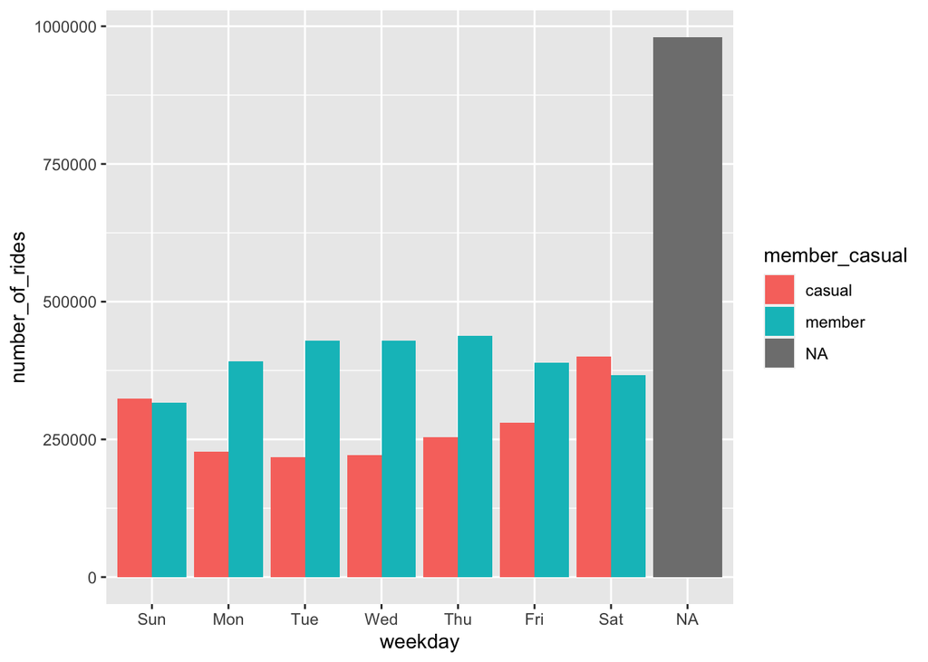

```r
# Let's visualize the number of rides by rider type
all_trips_v2 %>%
  mutate(weekday = wday(started_at, label = TRUE)) %>%
  group_by(member_casual, weekday) %>%
  summarise(number_of_rides = n()
            ,average_duration = mean(ride_length)) %>%
  arrange(member_casual, weekday)  %>%
  ggplot(aes(x = weekday, y = number_of_rides, fill = member_casual)) +
  geom_col(position = "dodge")
```

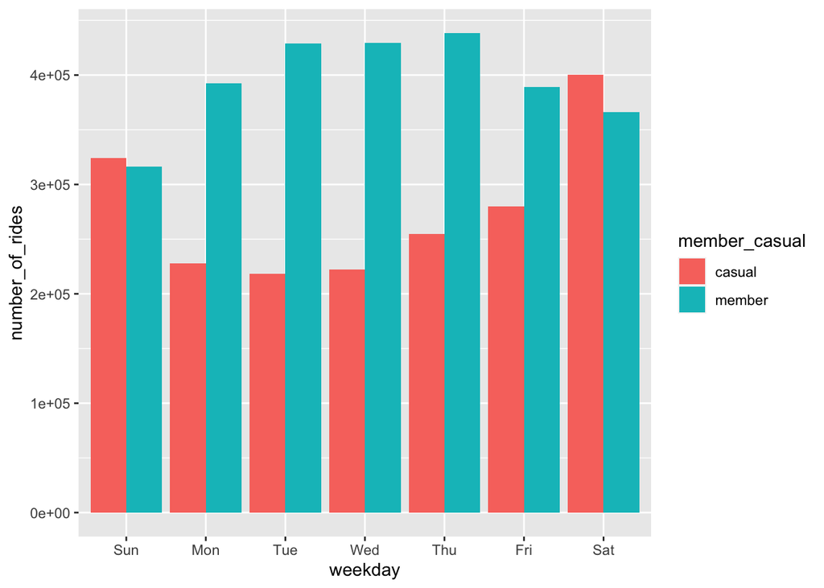

```r
all_trips_v2 %>%
  mutate(weekday = wday(started_at, label = TRUE)) %>%
  filter(!is.na(weekday)) %>% # Remove rows where weekday is NA
  group_by(member_casual, weekday) %>%
  summarise(number_of_rides = n()
            ,average_duration = mean(ride_length)) %>%
  arrange(member_casual, weekday)  %>%
  ggplot(aes(x = weekday, y = number_of_rides, fill = member_casual)) +
  geom_col(position = "dodge")
```

As you can see in the visualization the casual member use more in weekends and the members use more in weekday this can be useful we can use an ad for weekdays for workers and in weekends we can use an ad for casual to have a ride in the park or almost here in mexico city we have days that the avenue Reforma is closed and you can use the bicycle.

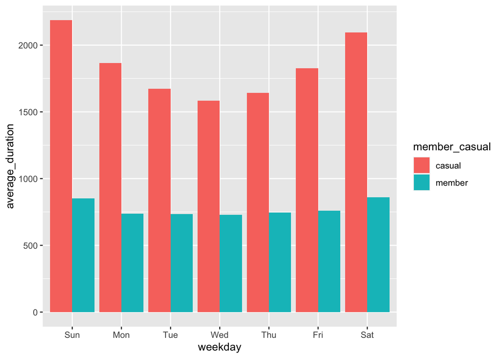

```r
# Let's create a visualization for average duration
all_trips_v2 %>%
  mutate(weekday = wday(started_at, label = TRUE)) %>%
  filter(!is.na(weekday)) %>%
  group_by(member_casual, weekday) %>%
  summarise(number_of_rides = n()
            ,average_duration = mean(ride_length)) %>%
  arrange(member_casual, weekday)  %>%
  ggplot(aes(x = weekday, y = average_duration, fill = member_casual)) +
  geom_col(position = "dodge")
```

### Step 5 Export summary file for further analysis

#### Create a csv file that we will visualize in Excel, Tableau, or my presentation software

```r
counts <- aggregate(all_trips_v2$ride_length ~ all_trips_v2$member_casual + all_trips_v2$day_of_week, FUN = mean)
```

```r
write.csv(counts, file = '/Users/donovanrodriguez/Documents/Database/avg_ride_length.csv')
```